# Ensemble Accuracy Test

Data was simulated with all events having a 6nm step plus a 2nm hitch. The rate of ADP-release was drawn from a truncated exponential distribution with minimum time of 1 millisecond and rate of 20/sec. This would take on average 50 milliseconds. Events were analyzed and ensemble averaged.

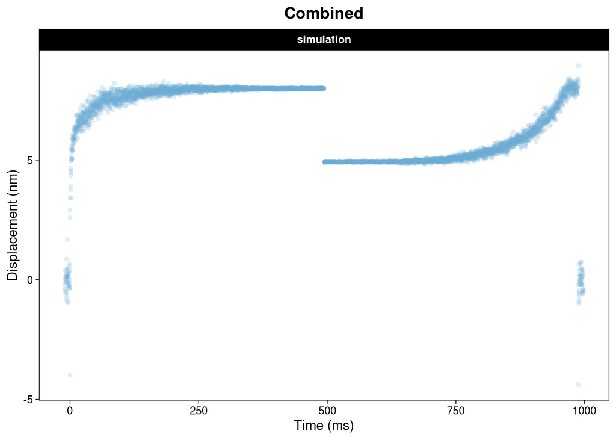

### k1

The rate of k1 was fit to estimate the rate of ADP release which was made to be 20/sec.

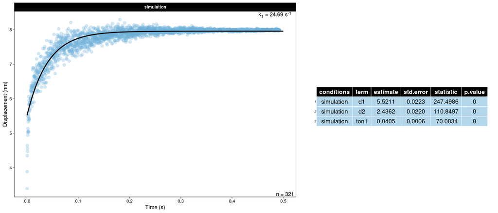

### k2

The backsides were fit with k2 to estimate the rate of ATP binding. ATP binding was simulated with a truncated exponential with a minimum time of 20 milliseconds and rate of 20/sec. The minimum time of 20 milliseconds was to play safe and ensure that there would be time post hitch to extend in the forward ensembles for this simulation.

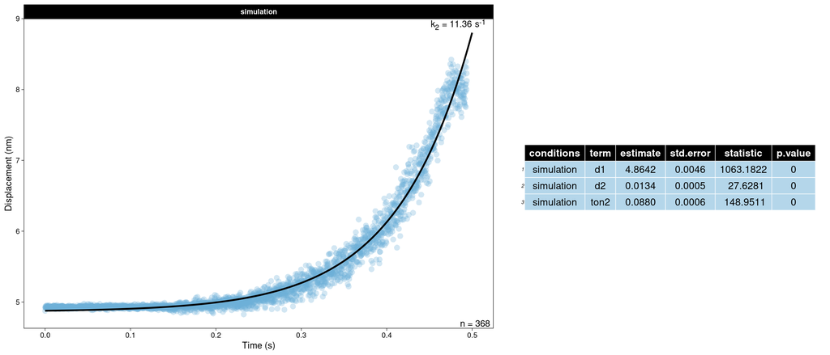

The estimate of 11/sec from k2 is not really that far off because the truncated exponential will not showcase the original rate of 20/sec due to not having the faster events that occur <20 milliseconds. The actual rate of the truncated distribution is around 14/sec making the estimate of 11/sec reasonable.

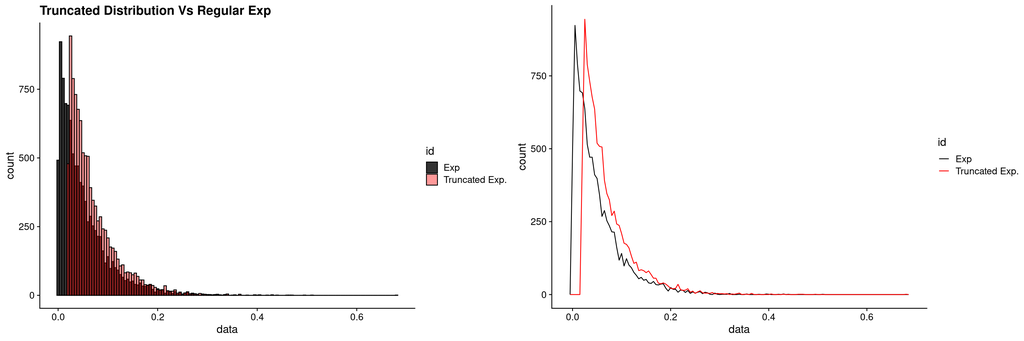

The mean and rate (1/mean) are summarized below.

```
## # A tibble: 2 x 3
##   id               mean  rate
##   <chr>           <dbl> <dbl>
## 1 Exp            0.0501  20.0
## 2 Truncated Exp. 0.0698  14.3
```